# nxG_extractfeature_descStats extracted from graphs

DataFrame.describe(percentiles=None, include=None, exclude=None)[source] Generates descriptive statistics that summarize the central tendency, dispersion and shape of a dataset’s distribution, excluding NaN values.

Analyzes both numeric and object series, as well as DataFrame column sets of mixed data types. The output will vary depending on what is provided. Refer to the notes below for more detail.

Parameters:  
percentiles : list-like of numbers, optional The percentiles to include in the output. All should fall between 0 and 1. The default is [.25, .5, .75], which returns the 25th, 50th, and 75th percentiles. include : ‘all’, list-like of dtypes or None (default), optional A white list of data types to include in the result. Ignored for Series. Here are the options: ‘all’ : All columns of the input will be included in the output.

A list-like of dtypes : Limits the results to the provided data types. To limit the result to numeric types submit numpy.number. To limit it instead to object columns submit the numpy.object data type. Strings can also be used in the style of select_dtypes (e.g. df.describe(include=['O'])). To select pandas categorical columns, use 'category'

None (default) : The result will include all numeric columns.

exclude : list-like of dtypes or None (default), optional,

A black list of data types to omit from the result. Ignored for Series. Here are the options:

A list-like of dtypes : Excludes the provided data types from the result. To exclude numeric types submit numpy.number. To exclude object columns submit the data type numpy.object. Strings can also be used in the style of select_dtypes (e.g. df.describe(include=['O'])). To exclude pandas categorical columns, use 'category' None (default) : The result will exclude nothing.

Returns:  
summary: Series/DataFrame of summary statistics

source: https://pandas.pydata.org/pandas-docs/stable/generated/pandas.DataFrame.describe.html

## Notes

For numeric data, the result’s index will include count, mean, std, min, max as well as lower, 50 and upper percentiles. By default the lower percentile is 25 and the upper percentile is 75. The 50 percentile is the same as the median.

For object data (e.g. strings or timestamps), the result’s index will include count, unique, top, and freq. The top is the most common value. The freq is the most common value’s frequency. Timestamps also include the first and last items.

If multiple object values have the highest count, then the count and top results will be arbitrarily chosen from among those with the highest count.

For mixed data types provided via a DataFrame, the default is to return only an analysis of numeric columns. If the dataframe consists only of object and categorical data without any numeric columns, the default is to return an analysis of both the object and categorical columns. If include='all' is provided as an option, the result will include a union of attributes of each type.

The include and exclude parameters can be used to limit which columns in a DataFrame are analyzed for the output. The parameters are ignored when analyzing a Series.

```python
# returning 18 variables
# discrall_Degree.columns
'''
Index([u'count', u'mean', u'std', u'min', u'25%', u'50%', u'75%', u'max',
   u'skew', u'kurt', u'var', u'cumsummean', u'cumsumstd', u'cumsummin',
   u'cumsum25%', u'cumsum50%', u'cumsum75%', u'cumsummax']
'''
```

```
"\nIndex([u'count', u'mean', u'std', u'min', u'25%', u'50%', u'75%', u'max',\n   u'skew', u'kurt', u'var', u'cumsummean', u'cumsumstd', u'cumsummin',\n   u'cumsum25%', u'cumsum50%', u'cumsum75%', u'cumsummax']\n"
```

# SAE: Autoencoder trainig and validation

## from NME_DEC/train_sae_wimgfeatures_descStats.py

```python
import sys
import os
import mxnet as mx
import numpy as np
import pandas as pd
import data
from scipy.spatial.distance import cdist
from sklearn.cluster import KMeans
import model
from autoencoder import AutoEncoderModel
from solver import Solver, Monitor
import logging
import sklearn
from sklearn.manifold import TSNE
from utilities import *
try:
   import cPickle as pickle
except:
   import pickle
import gzip

# for visualization
from sklearn.manifold import TSNE
from utilities import *
import matplotlib.pyplot as plt
%matplotlib inline
import seaborn as sns
```

```python
NME_nxgraphs = r'Z:\Cristina\Section3\paper_notes_section3_MODIFIED\datasets'

allNMEs_dynamic = pd.read_csv(os.path.join(NME_nxgraphs,'dyn_roi_records_allNMEs_descStats.csv'), index_col=0)

allNMEs_morphology = pd.read_csv(os.path.join(NME_nxgraphs,'morpho_roi_records_allNMEs_descStats.csv'), index_col=0)

allNMEs_texture = pd.read_csv(os.path.join(NME_nxgraphs,'text_roi_records_allNMEs_descStats.csv'), index_col=0)

allNMEs_stage1 = pd.read_csv(os.path.join(NME_nxgraphs,'stage1_roi_records_allNMEs_descStats.csv'), index_col=0)

# to load SERw matrices for all lesions
with gzip.open(os.path.join(NME_nxgraphs,'nxGdatafeatures_allNMEs_descStats.pklz'), 'rb') as fin:
    nxGdatafeatures = pickle.load(fin)

# to load discrall_dict dict for all lesions
with gzip.open(os.path.join(NME_nxgraphs,'nxGnormfeatures_allNMEs_descStats.pklz'), 'rb') as fin:
    discrall_dict_allNMEs = pickle.load(fin)

#########
# shape input (798L, 427L)
nxGdiscfeatures = discrall_dict_allNMEs
print('Loading {} leasions with nxGdiscfeatures of size = {}'.format(nxGdiscfeatures.shape[0], nxGdiscfeatures.shape[1]) )

print('Normalizing dynamic {} leasions with features of size = {}'.format(allNMEs_dynamic.shape[0], allNMEs_dynamic.shape[1]))
normdynamic = (allNMEs_dynamic - allNMEs_dynamic.mean(axis=0)) / allNMEs_dynamic.std(axis=0)
normdynamic.mean(axis=0)

print('Normalizing morphology {} leasions with features of size = {}'.format(allNMEs_morphology.shape[0], allNMEs_morphology.shape[1]))
normorpho = (allNMEs_morphology - allNMEs_morphology.mean(axis=0)) / allNMEs_morphology.std(axis=0)
normorpho.mean(axis=0)

print('Normalizing texture {} leasions with features of size = {}'.format(allNMEs_texture.shape[0], allNMEs_texture.shape[1]))
normtext = (allNMEs_texture - allNMEs_texture.mean(axis=0)) / allNMEs_texture.std(axis=0)
normtext.mean(axis=0)

print('Normalizing stage1 {} leasions with features of size = {}'.format(allNMEs_stage1.shape[0], allNMEs_stage1.shape[1]))
normstage1 = (allNMEs_stage1 - allNMEs_stage1.mean(axis=0)) / allNMEs_stage1.std(axis=0)
normstage1.mean(axis=0)

# shape input (798L, 427L)
combX_allNME = np.concatenate((nxGdiscfeatures, normdynamic.as_matrix(), normorpho.as_matrix(), normtext.as_matrix(), normstage1.as_matrix()), axis=1)
YnxG_allNME = np.asarray([nxGdatafeatures['roi_id'].values,
        nxGdatafeatures['classNME'].values,
        nxGdatafeatures['nme_dist'].values,
        nxGdatafeatures['nme_int'].values])

print('Loading {} all NME of size = {}'.format(combX_allNME.shape[0], combX_allNME.shape[1]) )
print('Loading all NME lables [label,BIRADS,dist,enh] of size = {}'.format(YnxG_allNME[0].shape[0])   )

# define variables for DEC
roi_labels = YnxG_allNME[1]
roi_labels = ['K' if rl=='U' else rl for rl in roi_labels]
```

```
Loading 792 leasions with nxGdiscfeatures of size = 326
Normalizing dynamic 792 leasions with features of size = 34
Normalizing morphology 792 leasions with features of size = 19
Normalizing texture 792 leasions with features of size = 44
Normalizing stage1 792 leasions with features of size = 100
Loading 792 all NME of size = 523
Loading all NME lables [label,BIRADS,dist,enh] of size = 792
```

```python
######################
## From Pre-train/fine tune the SAE
######################
save_to = r'Z:\Cristina\Section3\paper_notes_section3_MODIFIED\save_to\SAEmodels'
input_size = combX_allNME.shape[1]
latent_size = [input_size/rxf for rxf in [25,15,10,5,2]]

# train/test splits (test is 10% of labeled data)
sep = int(combX_allNME.shape[0]*0.10)
X_val = combX_allNME[:sep]
y_val = YnxG_allNME[1][:sep]
X_train = combX_allNME[sep:]
y_train = YnxG_allNME[1][sep:]
batch_size = 125 # 160 32*5 = update_interval*5
X_val[np.isnan(X_val)] = 0.00001

allAutoencoders = []
for output_size in latent_size:
    # Train or Read autoencoder: interested in encoding/decoding the input nxg features into LD latent space
    # optimized for clustering with DEC
    xpu = mx.cpu()
    ae_model = AutoEncoderModel(xpu, [X_train.shape[1],500,500,2000,output_size], pt_dropout=0.2)
    ##  After Pre-train and finetuuning on X_train
    ae_model.load( os.path.join(save_to,'SAE_zsize{}_wimgfeatures_descStats_zeromean.arg'.format(str(output_size))) )

    ##  Get train/valid error (for Generalization)
    print "Autoencoder Training error: %f"%ae_model.eval(X_train)
    print "Autoencoder Validation error: %f"%ae_model.eval(X_val)
    # put useful metrics in a dict
    outdict = {'Training set': ae_model.eval(X_train),
               'Testing set': ae_model.eval(X_val),
               'output_size': output_size,
               'sep': sep}

    allAutoencoders.append(outdict)
```

```
Autoencoder Training error: 0.000937
Autoencoder Validation error: 0.060106
Autoencoder Training error: 0.000890
Autoencoder Validation error: 0.042340
Autoencoder Training error: 0.000910
Autoencoder Validation error: 0.027583
Autoencoder Training error: 0.000802
Autoencoder Validation error: 0.017948
Autoencoder Training error: 0.000583
Autoencoder Validation error: 0.016800
```

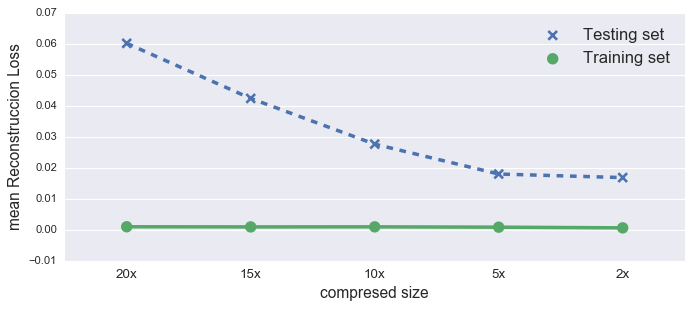

```python
######################
## Visualize the reconstructed inputs and the encoded representations.
######################
# train/test loss value o
dfSAE_perf = pd.DataFrame()
for SAE_perf in allAutoencoders:
    dfSAE_perf = dfSAE_perf.append( pd.DataFrame({'Reconstruction Error': pd.Series(SAE_perf)[0:2], 'train/validation':pd.Series(SAE_perf)[0:2].index, 'compressed size': SAE_perf['output_size']}) )

sns.set_style("darkgrid")
f, ax = plt.subplots(figsize=(10, 4))
sns.set_color_codes("pastel")
axSAE_perf = sns.pointplot(x="compressed size", y="Reconstruction Error", hue="train/validation", data=dfSAE_perf,
                           markers=["x","o"], linestyles=["--","-"])
aa=ax.set_xticklabels(['20x',"15x","10x","5x","2x"],fontsize=12)
ax.set_xlabel('compresed size',fontsize=14)
ax.set_ylabel('mean Reconstruccion Loss',fontsize=14)
ax.legend(loc="upper right",fontsize=15)
```

## LDx (after SAE no DEC) - Fitting aN MLP only after SAE

```python
## From Pre-train/fine tune the SAE
######################
from decModel_wimgF_dualopt_descStats import *
from utilities import *
import model

save_to = r'Z:\Cristina\Section3\paper_notes_section3_MODIFIED\save_to\SAEmodels'
input_size = combX_allNME.shape[1]
latent_size = [input_size/rxf for rxf in [15,10,5,2]]

scoresM = np.zeros((len(latent_size),5))
scoresM_titles=[]

sns.set_color_codes("pastel")

######################
# DEC: define num_centers according to clustering variable
######################
# to load a prevously DEC model
# to save all hyperparapsm
cvorigXAUC = [];
cvZspaceAUC_cvtrain = [];
cvZspace_stdAUC_cvtrain = [];
cvZspaceAUC_cvVal = [];
cvZspace_stdAUC_cvVal = [];
TestAUC = [];

valAUC = []
cv_SAEAUC = []
for ik,znum in enumerate(latent_size):
    X = combX_allNME
    y = roi_labels
    xpu = mx.cpu()
    ae_model = AutoEncoderModel(xpu, [X.shape[1],500,500,2000,znum], pt_dropout=0.2)
    print('Loading autoencoder of znum = {}, post training'.format(znum))
    ae_model.load( os.path.join(save_to,'SAE_zsize{}_wimgfeatures_descStats_zeromean.arg'.format(str(znum))) )

    data_iter = mx.io.NDArrayIter({'data': X},
                                  batch_size=X.shape[0], shuffle=False,
                                  last_batch_handle='pad')
    # extract only the encoder part of the SAE
    feature = ae_model.encoder
    zspace = model.extract_feature(feature, ae_model.args, None, data_iter, X.shape[0], xpu).values()[0]

    # pool Z-space variables
    datalabels = np.asarray(y)
    dataZspace = zspace

    #####################
    # unbiased assessment: SPlit train/held-out test
    #####################
    # to compare performance need to discard unkown labels, only use known labels (only B or M)
    Z = dataZspace[datalabels!='K',:]
    y = datalabels[datalabels!='K']

    print '\n... MLP fully coneected layer trained on Z_train tested on Z_test'
    sep = int(X.shape[0]*0.10)
    Z_test = Z[:sep]
    yZ_test = np.asanyarray(y[:sep]=='M').astype(int)
    Z_train = Z[sep:]
    yZ_train = np.asanyarray(y[sep:]=='M').astype(int)

    #####################
    # Z-space MLP fully coneected layer for classification
    #####################
    figROCs = plt.figure(figsize=(12,4))
    batch_size = 50
    # Run classifier with cross-validation and plot ROC curves
    cv = StratifiedKFold(n_splits=5, random_state=33)
    # Evaluate a score by cross-validation
    tprs_train = []; aucs_train = []
    tprs_val = []; aucs_val = []
    mean_fpr = np.linspace(0, 1, 100)
    cvi = 0
    ## to append pooled predictions
    pooled_pred_train = pd.DataFrame()
    pooled_pred_val = pd.DataFrame()
    for train, test in cv.split(Z_train, yZ_train):
        # Multilayer Perceptron
        MLP_train_iter = mx.io.NDArrayIter(Z_train[train], yZ_train[train], batch_size, shuffle=False)
        MLP_val_iter = mx.io.NDArrayIter(Z_train[test], yZ_train[test], batch_size)

        # We’ll define the MLP using MXNet’s symbolic interface
        dataMLP = mx.sym.Variable('data')
        #The following code declares two fully connected layers with 128 and 64 neurons each.
        #Furthermore, these FC layers are sandwiched between ReLU activation layers each
        #one responsible for performing an element-wise ReLU transformation on the FC layer output.
        # The first fully-connected layer and the corresponding activation function
        fc1  = mx.sym.FullyConnected(data=dataMLP, num_hidden = 128)
        act1 = mx.sym.Activation(data=fc1, act_type="relu")
        fc2  = mx.sym.FullyConnected(data=act1, num_hidden = 32)
        act2 = mx.sym.Activation(data=fc2, act_type="relu")
        # data has 2 classes
        fc3  = mx.sym.FullyConnected(data=act2, num_hidden=2)
        # Softmax with cross entropy loss
        mlp  = mx.sym.SoftmaxOutput(data=fc3, name='softmax')

        # create a trainable module on CPU
        mon = mx.mon.Monitor(interval=100, pattern='.*', sort=True); # Defaults to mean absolute value |x|/size(x)
        #checkpoint = mx.callback.do_checkpoint('mlp_model_params_z{}_mu{}.arg'.format(self.best_args['znum'],self.best_args['num_centers']))
        mlp_model = mx.mod.Module(symbol=mlp, context=mx.cpu())
        mlp_model.fit(MLP_train_iter,  # train data
                      optimizer='sgd',  # use SGD to train
                      optimizer_params={'learning_rate':0.01},  # use fixed learning rate
                      eval_metric= 'acc', #MLPacc(yZ_val, Z_val),  # report accuracy during trainin
                      monitor=mon,
                      num_epoch=850)
                      #epoch_end_callbackcheckpoint)  # train for at most 10 dataset passes. extras:               #monitor=mon,

        ############### on train
        prob_train = mlp_model.predict(MLP_train_iter)
        # Compute ROC curve and area the curve
        fpr_train, tpr_train, thresholds_train = roc_curve(yZ_train[train], prob_train.asnumpy()[:,1])
        # to create an ROC with 100 pts
        tprs_train.append(interp(mean_fpr, fpr_train, tpr_train))
        tprs_train[-1][0] = 0.0
        roc_auc = auc(fpr_train, tpr_train)
        aucs_train.append(roc_auc)

        ############### on validation
        # prob[i][j] is the probability that the i-th validation contains the j-th output class.
        prob_val = mlp_model.predict(MLP_val_iter)
        # Compute ROC curve and area the curve
        fpr_val, tpr_val, thresholds_val = roc_curve(yZ_train[test], prob_val.asnumpy()[:,1])
        # to create an ROC with 100 pts
        tprs_val.append(interp(mean_fpr, fpr_val, tpr_val))
        tprs_val[-1][0] = 0.0
        roc_auc = auc(fpr_val, tpr_val)
        aucs_val.append(roc_auc)
        # plot
        #axaroc.plot(fpr, tpr, lw=1, alpha=0.6) # with label add: label='cv %d, AUC %0.2f' % (cvi, roc_auc)
        cvi += 1
        # save for xnum 261 or 2x reduction
        if(ik==3):
            ## appends
            pooled_pred_train = pooled_pred_train.append( pd.DataFrame({"labels":yZ_train[train],
                                  "probC":prob_train.asnumpy()[:,1],
                                  "probNC":prob_train.asnumpy()[:,0]}), ignore_index=True)
```

```python
            pooled_pred_val = pooled_pred_val.append( pd.DataFrame({"labels":yZ_train[test],
                                  "probC":prob_val.asnumpy()[:,1],
                                  "probNC":prob_val.asnumpy()[:,0]}), ignore_index=True)

    # plot for cv Train
    axaroc_train = figROCs.add_subplot(1,3,1)
    # add 50% or chance line
    axaroc_train.plot([0, 1], [0, 1], linestyle='--', lw=1, color='b', alpha=.9)
    # plot mean and +- 1 -std as fill area
    mean_tpr_train = np.mean(tprs_train, axis=0)
    mean_tpr_train[-1] = 1.0
    mean_auc_train = auc(mean_fpr, mean_tpr_train)
    std_auc_train = np.std(aucs_train)
    axaroc_train.plot(mean_fpr, mean_tpr_train, color='b',
                label=r'cv Train (AUC = %0.2f $\pm$ %0.2f)' % (mean_auc_train, std_auc_train),lw=3, alpha=1)
    std_tpr = np.std(tprs_train, axis=0)
    tprs_upper = np.minimum(mean_tpr_train + std_tpr, 1)
    tprs_lower = np.maximum(mean_tpr_train - std_tpr, 0)
    axaroc_train.fill_between(mean_fpr, tprs_lower, tprs_upper, color='grey', alpha=.2,label=r'$\pm$ 1 std. dev.')
    # set labels
    axaroc_train.set_xlabel('False Positive Rate',fontsize=16)
    axaroc_train.set_ylabel('True Positive Rate',fontsize=16)
    axaroc_train.set_title('SAE Zspace + cv MLP classifier Zspace dim={}'.format(Z.shape[1]),fontsize=18)
    axaroc_train.legend(loc="lower right",fontsize=16)

    # plot for cv val
    axaroc_val = figROCs.add_subplot(1,3,2)
    # add 50% or chance line
    axaroc_val.plot([0, 1], [0, 1], linestyle='--', lw=1, color='b', alpha=.9)
    # plot mean and +- 1 -std as fill area
    mean_tpr_val = np.mean(tprs_val, axis=0)
    mean_tpr_val[-1] = 1.0
    mean_auc_val = auc(mean_fpr, mean_tpr_val)
    std_auc_val = np.std(aucs_val)
    axaroc_val.plot(mean_fpr, mean_tpr_val, color='g',
                label=r'cv Val (AUC = %0.2f $\pm$ %0.2f)' % (mean_auc_val, std_auc_val),lw=3, alpha=1)
    std_tpr = np.std(tprs_val, axis=0)
    tprs_upper = np.minimum(mean_tpr_val + std_tpr, 1)
    tprs_lower = np.maximum(mean_tpr_val - std_tpr, 0)
    axaroc_val.fill_between(mean_fpr, tprs_lower, tprs_upper, color='grey', alpha=.2,label=r'$\pm$ 1 std. dev.')
    # set labels
    axaroc_val.set_xlabel('False Positive Rate',fontsize=16)
    axaroc_val.set_ylabel('True Positive Rate',fontsize=16)
    axaroc_val.legend(loc="lower right",fontsize=16)

    ################
    # plot AUC on heldout set
    ################
    MLP_heldout_iter = mx.io.NDArrayIter(Z_test, None, batch_size)
    probas_heldout = mlp_model.predict(MLP_heldout_iter)

    # plot for cv val
    axaroc_test = figROCs.add_subplot(1,3,3)
    # add 50% or chance line
    axaroc_test.plot([0, 1], [0, 1], linestyle='--', lw=1, color='b', alpha=.9)
    # Compute ROC curve and area the curve
    fpr_test, tpr_test, thresholds_test = roc_curve(yZ_test, probas_heldout.asnumpy()[:, 1])
    auc_test = auc(fpr_test, tpr_test)
    axaroc_test.plot(fpr_test, tpr_test, color='r',
                label=r'Test (AUC = %0.2f)' % (auc_test),lw=3, alpha=1)
    # set labels
    axaroc_test.set_xlabel('False Positive Rate',fontsize=16)
    axaroc_test.set_ylabel('True Positive Rate',fontsize=16)
    axaroc_test.legend(loc="lower right",fontsize=16)
    plt.show()

    ############# append to
    cvorigXAUC.append(0.69)
    cvZspaceAUC_cvtrain.append(mean_auc_train)
    cvZspace_stdAUC_cvtrain.append(std_auc_train)
    cvZspaceAUC_cvVal.append(mean_auc_val)
    cvZspace_stdAUC_cvVal.append(std_auc_val)
    TestAUC.append(auc_test)

    ############# append to
    cv_SAEAUC.append(mean_auc_val)
    valAUC.append(auc_test)
    scoresM[ik,0] = mean_auc_train
    scoresM_titles.append("SAE cv mean_auc_train")
    scoresM[ik,1] = std_auc_train
    scoresM_titles.append("SAE cv std_auc_train")
    scoresM[ik,2] = mean_auc_val
    scoresM_titles.append("SAE cv mean_auc_val")
    scoresM[ik,3] = std_auc_val
    scoresM_titles.append("SAE cv std_auc_val")
    scoresM[ik,4] = auc_test
    scoresM_titles.append("SAE held-out test AUC")

    ######################
    # Combined ROCs
    ######################
     # plot for cv Train
    figROCs = plt.figure(figsize=(5,5))
    axaroc = figROCs.add_subplot(1,1,1)
    # add 50% or chance line
    axaroc.plot([0, 1], [0, 1], linestyle='--', lw=1, color='b', alpha=.9)
    # plot mean and +- 1 -std as fill area
    mean_tpr_train = np.mean(tprs_train, axis=0)
    mean_tpr_train[-1] = 1.0
    mean_auc_train = auc(mean_fpr, mean_tpr_train)
    std_auc_train = np.std(aucs_train)
    axaroc.plot(mean_fpr, mean_tpr_train, color='b',
                label=r'cv Train (AUC = %0.2f $\pm$ %0.2f)' % (mean_auc_train, std_auc_train),lw=3, alpha=1)
    std_tpr = np.std(tprs_train, axis=0)
    tprs_upper = np.minimum(mean_tpr_train + std_tpr, 1)
    tprs_lower = np.maximum(mean_tpr_train - std_tpr, 0)
    axaroc.fill_between(mean_fpr, tprs_lower, tprs_upper, color='grey', alpha=.2,label=r'$\pm$ 1 std. dev.')

    # plot for cv val
    mean_tpr_val = np.mean(tprs_val, axis=0)
    mean_tpr_val[-1] = 1.0
    mean_auc_val = auc(mean_fpr, mean_tpr_val)
    std_auc_val = np.std(aucs_val)
    axaroc.plot(mean_fpr, mean_tpr_val, color='g',
                label=r'cv Val (AUC = %0.2f $\pm$ %0.2f)' % (mean_auc_val, std_auc_val),lw=3, alpha=1)
    std_tpr = np.std(tprs_val, axis=0)
    tprs_upper = np.minimum(mean_tpr_val + std_tpr, 1)
    tprs_lower = np.maximum(mean_tpr_val - std_tpr, 0)
    axaroc.fill_between(mean_fpr, tprs_lower, tprs_upper, color='grey', alpha=.2,label=r'$\pm$ 1 std. dev.')

    ################
    # plot AUC on heldout set
    ################
    MLP_heldout_iter = mx.io.NDArrayIter(Z_test, None, batch_size)
    probas_heldout = mlp_model.predict(MLP_heldout_iter)

    # plot for axaroc
    # add 50% or chance line
    axaroc.plot([0, 1], [0, 1], linestyle='--', lw=1, color='b', alpha=.9)
    # Compute ROC curve and area the curve
    fpr_test, tpr_test, thresholds_test = roc_curve(yZ_test, probas_heldout.asnumpy()[:, 1])
    auc_test = auc(fpr_test, tpr_test)
    axaroc.plot(fpr_test, tpr_test, color='r',
                label=r'Test (AUC = %0.2f)' % (auc_test),lw=3, alpha=1)
    # set labels
    axaroc.set_xlabel('False Positive Rate',fontsize=16)
    axaroc.set_ylabel('True Positive Rate',fontsize=16)
    axaroc.set_title('Unsupervised DEC + cv MLP classifier Zspace dim={}'.format(znum),fontsize=18)
    axaroc.legend(loc="lower right",fontsize=16)
    plt.show()
```

```
Loading autoencoder of znum = 34, post training

... MLP fully coneected layer trained on Z_train tested on Z_test
```

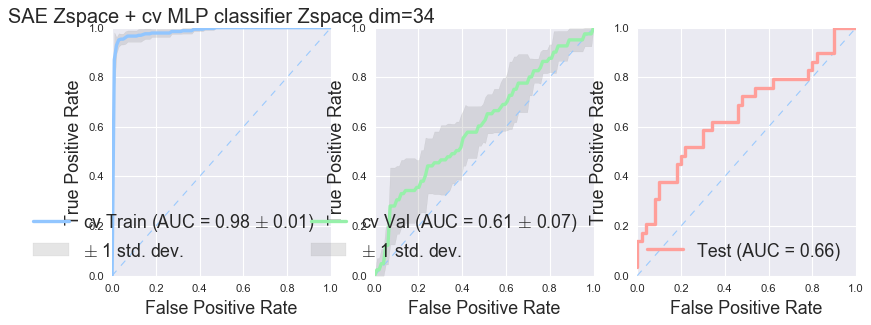

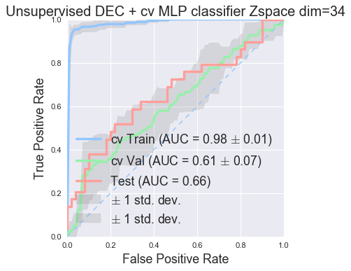

```
Loading autoencoder of znum = 52, post training

... MLP fully coneected layer trained on Z_train tested on Z_test
```

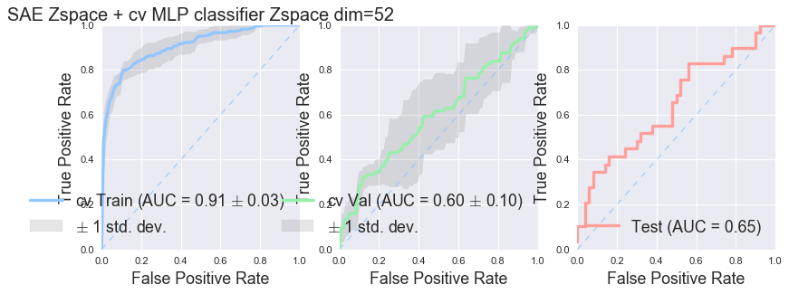

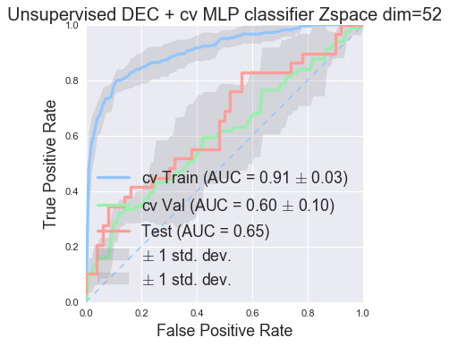

```
Loading autoencoder of znum = 104, post training

... MLP fully coneected layer trained on Z_train tested on Z_test
```

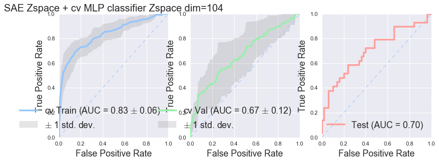

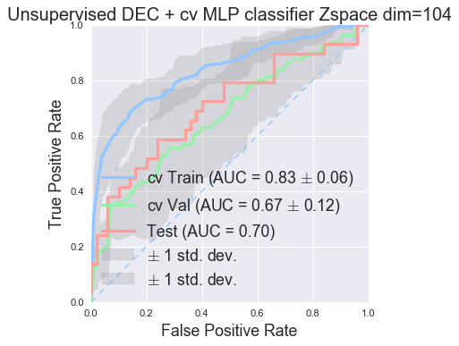

```
Loading autoencoder of znum = 261, post training

... MLP fully coneected layer trained on Z_train tested on Z_test
```

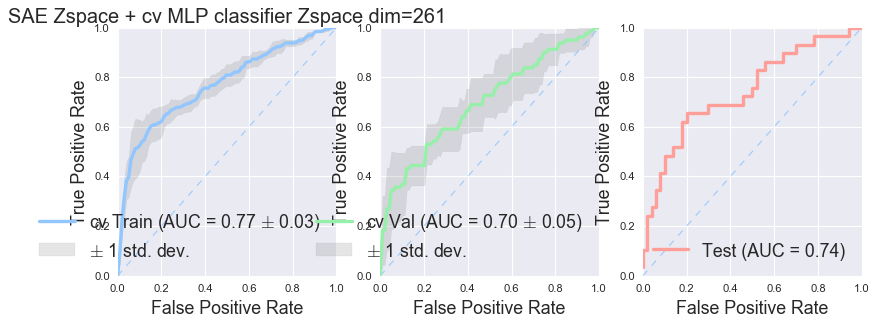

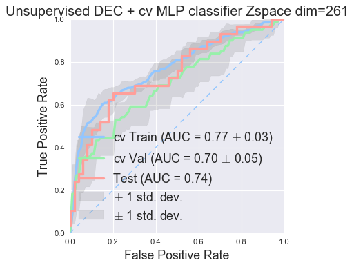

```python
    if(ik==3):
        pred_test = pd.DataFrame({"labels":yZ_test,
                          "probC":probas_heldout.asnumpy()[:,1],
                          "probNC":probas_heldout.asnumpy()[:,0]})
```

```python
################
# to hold the hyperparams
grd = np.array([zs for zs in latent_size])
grdperf_SAE = pd.DataFrame(grd)
grdperf_SAE.columns = ["Zsize"]

# finish fromating DEC performance
grdperf_SAE['cvorigXAUC'] = cvorigXAUC
grdperf_SAE['cvZspaceAUC_cvtrain'] = cvZspaceAUC_cvtrain
grdperf_SAE['cvZspace_stdAUC_cvtrain'] = cvZspace_stdAUC_cvtrain
grdperf_SAE['cvZspaceAUC_cvVal'] = cvZspaceAUC_cvVal
grdperf_SAE['cvZspace_stdAUC_cvVal'] = cvZspace_stdAUC_cvVal
grdperf_SAE['TestAUC'] = TestAUC
print(grdperf_SAE)


# save pooled model probabilties
grdperf_SAE.to_csv('datasets/grdperf_SAE.csv', header=True, index=False)
```

```
   Zsize  cvorigXAUC  cvZspaceAUC_cvtrain  cvZspace_stdAUC_cvtrain  \
0     34        0.69             0.983892                 0.005991
1     52        0.69             0.905260                 0.030648
2    104        0.69             0.832400                 0.061864
3    261        0.69             0.769409                 0.032242

   cvZspaceAUC_cvVal  cvZspace_stdAUC_cvVal   TestAUC
0           0.610532               0.074219  0.659310
1           0.598960               0.102360  0.645517
2           0.668486               0.118485  0.704828
3           0.697007               0.053874  0.744828
```

```
znum = 34 , post training DEC results
auc train cv, at knum centroids 0.983891802642
std auc train cv, at knum centroids 0.00599082823945
auc val cv, at knum centroids 0.610531788473
std of max auc val cv, at knum centroids 0.0742188823639
held out auc, at knum centroids 0.659310344828
znum = 52 , post training DEC results
auc train cv, at knum centroids 0.90526029526
std auc train cv, at knum centroids 0.0306483344986
auc val cv, at knum centroids 0.598960190137
std of max auc val cv, at knum centroids 0.102359539774
held out auc, at knum centroids 0.645517241379
znum = 104 , post training DEC results
auc train cv, at knum centroids 0.83239996115
std auc train cv, at knum centroids 0.061864194875
auc val cv, at knum centroids 0.668486333928
std of max auc val cv, at knum centroids 0.118485311113
held out auc, at knum centroids 0.704827586207
znum = 261 , post training DEC results
auc train cv, at knum centroids 0.769408508159
std auc train cv, at knum centroids 0.0322424736111
auc val cv, at knum centroids 0.697006833036
std of max auc val cv, at knum centroids 0.0538738126249
held out auc, at knum centroids 0.744827586207
```

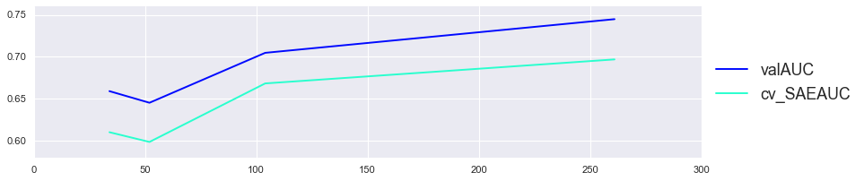

```python
# plot latent space Accuracies vs. original
colors = plt.cm.jet(np.linspace(0, 1, 16))
fig2 = plt.figure(figsize=(12,6))
#ax2 = plt.axes()
sns.set_context("notebook")
ax1 = fig2.add_subplot(2,1,1)
ax1.plot(latent_size, valAUC, color=colors[2], label='valAUC')
ax1.plot(latent_size, cv_SAEAUC, color=colors[6], label='cv_SAEAUC')
h1, l1 = ax1.get_legend_handles_labels()
ax1.legend(h1, l1, loc='center left', bbox_to_anchor=(1, 0.5), prop={'size':16})

######################
# Combined ROCs
######################
for u, znum in enumerate(latent_size):
    print('znum = {} , post training DEC results'.format(znum))
    max_test_val = scoresM[u,4]
    print "auc train cv, at knum centroids", scoresM[u,0]
    print "std auc train cv, at knum centroids", scoresM[u,1]
    print "auc val cv, at knum centroids", scoresM[u,2]
    print "std of max auc val cv, at knum centroids", scoresM[u,3]
    print "held out auc, at knum centroids", scoresM[u,4]
```

```python
pooled_pred_val
```

|  | labels | probC | probNC |
| --- | --- | --- | --- |
| 0 | 0 | 0.272397 | 0.727603 |
| 1 | 0 | 0.322464 | 0.677536 |
| 2 | 1 | 0.569672 | 0.430328 |
| 3 | 1 | 0.243260 | 0.756740 |
| 4 | 0 | 0.284929 | 0.715071 |
| 5 | 1 | 0.324599 | 0.675401 |
| 6 | 0 | 0.218010 | 0.781990 |
| 7 | 0 | 0.158814 | 0.841186 |
| 8 | 0 | 0.205428 | 0.794572 |
| 9 | 0 | 0.223847 | 0.776153 |
| 10 | 0 | 0.350743 | 0.649257 |
| 11 | 0 | 0.242272 | 0.757728 |
| 12 | 1 | 0.384107 | 0.615893 |
| 13 | 0 | 0.147780 | 0.852220 |
| 14 | 1 | 0.502184 | 0.497816 |
| 15 | 1 | 0.501960 | 0.498040 |
| 16 | 0 | 0.313019 | 0.686981 |
| 17 | 0 | 0.165448 | 0.834552 |
| 18 | 1 | 0.556902 | 0.443098 |
| 19 | 1 | 0.429378 | 0.570622 |
| 20 | 1 | 0.341259 | 0.658741 |
| 21 | 1 | 0.369298 | 0.630702 |
| 22 | 0 | 0.235969 | 0.764031 |
| 23 | 0 | 0.131186 | 0.868814 |
| 24 | 1 | 0.425543 | 0.574457 |
| 25 | 0 | 0.189608 | 0.810392 |
| 26 | 0 | 0.349195 | 0.650805 |
| 27 | 1 | 0.296327 | 0.703673 |
| 28 | 0 | 0.295691 | 0.704309 |
| 29 | 0 | 0.279626 | 0.720374 |
| ... | ... | ... | ... |
| 268 | 0 | 0.140514 | 0.859486 |
| 269 | 0 | 0.267380 | 0.732620 |
| 270 | 0 | 0.354225 | 0.645775 |
| 271 | 0 | 0.222119 | 0.777881 |
| 272 | 0 | 0.221674 | 0.778326 |
| 273 | 0 | 0.593349 | 0.406651 |
| 274 | 0 | 0.276880 | 0.723120 |
| 275 | 0 | 0.384036 | 0.615964 |
| 276 | 0 | 0.244225 | 0.755775 |
| 277 | 1 | 0.419784 | 0.580216 |
| 278 | 1 | 0.486146 | 0.513854 |
| 279 | 1 | 0.187806 | 0.812194 |
| 280 | 1 | 0.173793 | 0.826207 |
| 281 | 1 | 0.170567 | 0.829433 |
| 282 | 1 | 0.422977 | 0.577023 |
| 283 | 1 | 0.438436 | 0.561564 |
| 284 | 1 | 0.417700 | 0.582300 |
| 285 | 1 | 0.252230 | 0.747770 |
| 286 | 1 | 0.327719 | 0.672281 |
| 287 | 1 | 0.248974 | 0.751026 |
| 288 | 0 | 0.204550 | 0.795450 |
| 289 | 0 | 0.177680 | 0.822320 |
| 290 | 1 | 0.663140 | 0.336860 |
| 291 | 0 | 0.428728 | 0.571272 |
| 292 | 0 | 0.185351 | 0.814649 |
| 293 | 1 | 0.312302 | 0.687698 |
| 294 | 1 | 0.649764 | 0.350236 |
| 295 | 1 | 0.197144 | 0.802856 |
| 296 | 0 | 0.263988 | 0.736012 |
| 297 | 1 | 0.320063 | 0.679937 |

298 rows × 3 columns

```python
################
# save pooled model probabilties
pooled_pred_train.to_csv('datasets/exp2_pooled_pred_train.csv', header=True, index=False)
pooled_pred_val.to_csv('datasets/exp2_pooled_pred_val.csv', header=True, index=False)
pred_test.to_csv('datasets/exp2_pred_test.csv', header=True, index=False)
```